# MolluscaBase

Fonti Kar

2023-06-19

[MolluscaBase](https://www.molluscabase.org/index.php) is a branch of the [World Register of Marine Species](https://www.marinespecies.org/) (WoRMs), this means that we can use WoRMS tools to get the data we need - score!

```r
# Read in AFD
afd_may <- read_csv_arrow(here("data/afd_May2023_clean.csv"))
```

## MatchTool

MatchTool is available on [MolluscaBase](https://www.molluscabase.org/aphia.php?p=match) and [WoRMS](https://www.marinespecies.org/aphia.php?p=match), to match a user’s taxonomic list to their database to verify any changes taxonomic updates/typos.

This is a great method to shows what’s in AFD and not in MolluscaBase/WoRMs, but first we need to prepare our data for these tools.

### Filter out Molluscs from AFD

Here we are filtering out data for Molluscs only.

```r
# Filter to Molluscs and select the column we need
molluscs_afd <- afd_may |> filter(
  PHYLUM == "MOLLUSCA"
) |>
  select(COMPLETE_NAME)

nrow(molluscs_afd)
```

```
## [1] 2039
```

```r
print(molluscs_afd, n = 6)
```

```
## # A tibble: 2,039 × 1
##   COMPLETE_NAME
##   <chr>
## 1 Abralia astrostricta, Berry 1909
## 2 Acanthopleura curtisiana, E.A. Smith 1884
## 3 Acanthopleura hirtosa, Blainville 1825
## 4 Achatina fulica, Bowdich 1822
## 5 Acheronopa attunga, Hyman & Stanisic 2005
## 6 Adclarkia cameroni, Stanisic 2010
## # ℹ 2,033 more rows
```

```r
# Save Mollusca
# write_csv(matchtool, "outputs/AFD_May_Molluscs.csv")
```

Here we are creating our own scientific name and authority variable as this was not included as a separate column in the AFD dataset.

```r
# Split COMPLETE_NAME to create authority and scientific name
molluscs_afd_authority <- molluscs_afd |>
  mutate(split = map(.x = COMPLETE_NAME,
                         ~str_split(.x, pattern = ", ")),
         scientific_name = map(split,
                         ~pluck(.x, 1, 1)),
         authority = map(split,
                         ~pluck(.x, 1, 2))) |>
  select(-c(split, COMPLETE_NAME)) |>
  unnest(cols = c("scientific_name","authority"))

molluscs_afd_authority |> print(n = 6)
```

```
## # A tibble: 2,039 × 2
##   scientific_name          authority
##   <chr>                    <chr>
## 1 Abralia astrostricta     Berry 1909
## 2 Acanthopleura curtisiana E.A. Smith 1884
## 3 Acanthopleura hirtosa    Blainville 1825
## 4 Achatina fulica          Bowdich 1822
## 5 Acheronopa attunga       Hyman & Stanisic 2005
## 6 Adclarkia cameroni       Stanisic 2010
## # ℹ 2,033 more rows
```

One limitation to the Matchtool on the website is that it can only accept files of 1499 rows (1500 technically but column headers is count as one!). So here we are splitting the dataset into chunks of 1499 rows and export as an Excel file (a hack from Frank Koehler so the commas in the authority doesn’t affect the matches).

```r
# Split so it has 1500 rows in total
chunk <- 1499
n <- nrow(molluscs_afd_authority)
r  <- rep(1:ceiling(n/chunk),each=chunk)[1:n]
d <- split(molluscs_afd_authority,r)

d
```

```
## $`1`
## # A tibble: 1,499 × 2
##    scientific_name          authority
##    <chr>                    <chr>
##  1 Abralia astrostricta     Berry 1909
##  2 Acanthopleura curtisiana E.A. Smith 1884
##  3 Acanthopleura hirtosa    Blainville 1825
##  4 Achatina fulica          Bowdich 1822
##  5 Acheronopa attunga       Hyman & Stanisic 2005
##  6 Adclarkia cameroni       Stanisic 2010
##  7 Adclarkia dawsonensis    Stanisic 1996
##  8 Adclarkia dulacca        Stanisic 2010
##  9 Advena campbellii        Gray 1834
## 10 Advena charon            Preston 1913
## # ℹ 1,489 more rows
##
## $`2`
## # A tibble: 540 × 2
##    scientific_name       authority
##    <chr>                 <chr>
##  1 Pyrgulina declivita   Laseron 1959
##  2 Pyrgulina kreffti     Angas 1867
##  3 Pyrgulina nugatoria   Hedley 1903
##  4 Pyrgulina pascoei     Angas 1867
##  5 Pyrgulina punctigera  A. Adams 1860
##  6 Pyrgulina reticulata  Laseron 1959
##  7 Pyrgulina univestis   Laseron 1959
##  8 Pyrgulina vincentina  Tryon 1886
##  9 Pythia scarabaeus     Linnaeus 1758
## 10 Queridomus grenvillei Brazier 1876
## # ℹ 530 more rows
```

```r
# Assign the list with useful names
names(d) <- paste0("May_AFD_Mollusca_matchtool_", names(d))

names(d)
```

```
## [1] "May_AFD_Mollusca_matchtool_1" "May_AFD_Mollusca_matchtool_2"
```

```r
# Save each chunk as .csv
# walk2(.x = d, .y = names(d),
#      ~write_xlsx(.x, path = here(paste0("outputs/", .y, ".xlsx")))
```

Once I exported these files, we have to go to the Matchtool on MB website.

I uploaded these and selected the following options:

- Check Match authority
- Match up to ScientificName
- Check Match against MolluscaBase
- Selected authority in addition to defaults in Outputs

In the preview mode, the app shows you what variable your column headers are likely to be:

scientific_name ~ ScientificName authority ~ ScientificNameAuthor

Matching takes a few moments once complete, you can save the output as.

If there are an ambiguous matches, the tool allows you to try clarify them by providing species name + authority to select from the drop down menu.

### Read in output from Matchtool

```r
matched_output_1 <- read_xlsx(here("data/may_afd_mollusca_matchtool_1_matched.xlsx")) |>
  select(-3) |>
  rename(afd_scientific_name = scientific_name)
matched_output_2 <- read_xlsx(here("data/may_afd_mollusca_matchtool_2_matched.xlsx")) |>
  select(-3) |>
  rename(afd_scientific_name = scientific_name)
# Bind these together
mb_output_matchtools <- bind_rows(matched_output_1, matched_output_2) |>
  clean_names()

# Check that these are the same as input
nrow(mb_output_matchtools) == nrow(molluscs_afd_authority)
```

```
## [1] TRUE
```

### Investigate output from MatchTools

Match type categories:

- `exact` all characters match exactly
- `exact_subgenus` an exact match, but including the subgenus
- `phonetic` sounds similar as, despite minor differences in spelling (soundex algorithm)
- `near_1` perfect match, except for one character. This is a quite reliable match
- `near_2` good match, except for two characters. This needs an extra check
- `near_3` good match, except for three characters. This definitely needs an extra check
- `match_quarantine` match with a name that is currently in quarantine. Any name that has been used in the - literature should in principle not be quarantined. So best to contact the WoRMS DMT about this
- `match_deleted` this is a match with a name that has been deleted and no alternative is available. Please contact the WoRMS DMT when you come across this.

```r
mb_output_matchtools |>
  pull(match_type) |>
  tabyl()
```

```
##  pull(mb_output_matchtools, match_type)    n      percent valid_percent
##                               ambiguous    1 0.0004904365  0.0005015045
##                                   exact 1931 0.9470328592  0.9684052156
##                          exact_subgenus    1 0.0004904365  0.0005015045
##                                  near_1    9 0.0044139284  0.0045135406
##                                  near_2   37 0.0181461501  0.0185556670
##                                  near_3    1 0.0004904365  0.0005015045
##                                phonetic   14 0.0068661108  0.0070210632
##                                    <NA>   45 0.0220696420            NA
```

#### Taxa MolluscaBase can add

```r
mb_output_matchtools |>
  filter(is.na(match_type))
```

```
## # A tibble: 45 × 9
##    afd_scientific_name authority aphia_id match_type scientific_name authority_2
##    <chr>               <chr>        <dbl> <chr>      <chr>           <chr>
##  1 Alathyria pertexta… Iredale …       NA <NA>       <NA>            <NA>
##  2 Allenella belli be… Iredale …       NA <NA>       <NA>            <NA>
##  3 Auriocorona queens… Golding …       NA <NA>       <NA>            <NA>
##  4 Caryodes dufresnii… Leach 18…       NA <NA>       <NA>            <NA>
##  5 Chrysallida exserta Laseron …       NA <NA>       <NA>            <NA>
##  6 Chrysallida henni   Brazier …       NA <NA>       <NA>            <NA>
##  7 Chrysallida spirata A. Adams…       NA <NA>       <NA>            <NA>
##  8 Cingulina triarata  Pilsbry …       NA <NA>       <NA>            <NA>
##  9 Colsyrnola acicula… A. Adams…       NA <NA>       <NA>            <NA>
## 10 Didimarcar tenebri… Reeve 18…       NA <NA>       <NA>            <NA>
## # ℹ 35 more rows
## # ℹ 3 more variables: aphia_id_accepted <dbl>, scientific_name_accepted <chr>,
## #   authority_accepted <chr>
```

```r
n_mb_additions <- mb_output_matchtools |>
  filter(is.na(match_type)) |>
  nrow()
```

We found 45 names that exist in the AFD that are not in MolluscaBase. Send these to Frank Koehler.

#### Taxa AFD can correct

These need to be checked but, from a quick look, these look like typos by the AFD.

```r
mb_output_matchtools |>
  filter(str_detect(match_type, "near")) |>
  select(ends_with("name")) |>
  print(n = 50)
```

```
## # A tibble: 47 × 2
##    afd_scientific_name         scientific_name
##    <chr>                       <chr>
##  1 Abralia astrostricta        Abralia astrosticta
##  2 Aliculastrum tumida         Aliculastrum tumidum
##  3 Allopeas clavulinus         Allopeas clavulinum
##  4 Alluroteuthis antarctica    Alluroteuthis antarcticus
##  5 Ancylastrum cumingianus     Ancylastrum cumingianum
##  6 Chrysallida caelatior       Chrysallida caelatura
##  7 Cirsotrema fimbriolata      Cirsotrema fimbriolatum
##  8 Cirsotrema multiperforata   Cirsotrema multiperforatum
##  9 Ctenopteryx siculus         Ctenopteryx sicula
## 10 Cupedora extensum           Cupedora extensa
## 11 Cyclochlamys gaussianus     Cyclochlamys gaussiana
## 12 Epitonium clementina        Epitonium clementinum
```

[output cut: 35 more lines]

```r
n_typos <- mb_output_matchtools |>
  filter(str_detect(match_type, "near"))  |>
  nrow()
```

We found 47 AFD names (2.31% of Molluscs) that can be corrected. Send these to Matt and Hayley at AFD

#### Phonetic taxa

Visually inspect these to see how close they are. These look like typos to me by the AFD, needs to be checked by JM or JK Once confirmed, send these to Matt and Hayley at AFD to correct

```r
mb_output_matchtools |>
  filter(match_type == "phonetic")  |>
  select(ends_with("name"))
```

```
## # A tibble: 14 × 2
##    afd_scientific_name           scientific_name
##    <chr>                         <chr>
##  1 Amerianna cumingi             Amerianna cumingii
##  2 Ancistrocheirus lesueuri      Ancistrocheirus lesueurii
##  3 Callistochiton occidus        Callistochiton occiduus
##  4 Epiglypta howinsulae          Epiglypta howeinsulae
##  5 Kosciuskoropa nivea           Kosciuszkoropa nivea
##  6 Liocranchia reinhardti        Liocranchia reinhardtii
##  7 Liocranchia valdivae          Liocranchia valdiviae
##  8 Pareledone harrisoni          Pareledone harrissoni
##  9 Rhachis punctatus             Rachis punctatus
## 10 Sacoproteus yihae             Sacoproteus yhiae
## 11 Sermyla riqueti               Sermyla riquetii
## 12 Taonius suhmii                Taonius suhmi
## 13 Tetronychoteuthis dussumierii Tetronychoteuthis dussumieri
## 14 Velepalaina dunkiensis        Velepalaina dunkensis
```

#### Ambiguous taxa

These need to be followed up with JM/JK or Frank. Exporting these and putting into MatchTool again shows there are 2 possible `near_3` matches:

- Turbonilla scalarina Brazier, 1894 accepted as Turbonilla beddomei (Petterd, 1884) [near_3]
- Turbonilla subconica W. H. Turton, 1932 [near_3]

```r
mb_output_matchtools |>
  filter(match_type == "ambiguous")
```

```
## # A tibble: 1 × 9
##   afd_scientific_name  authority aphia_id match_type scientific_name authority_2
##   <chr>                <chr>        <dbl> <chr>      <chr>           <chr>
## 1 Turbonilla subcarina Laseron …       NA ambiguous  <NA>            <NA>
## # ℹ 3 more variables: aphia_id_accepted <dbl>, scientific_name_accepted <chr>,
## #   authority_accepted <chr>
```

```r
mb_output_matchtools |>
  filter(match_type == "ambiguous") |> nrow()
```

```
## [1] 1
```

```r
# mb_output_matchtools |>
#   filter(match_type == "ambiguous") |>
#   select(afd_scientific_name, authority) |>
#   write_xlsx(here("outputs/May_AFD_ambiguous_molluscs_matchtool.xlsx"))
```

### WoRMS API in replacement of MatchTool

Instead of the manual approach above, there is a R package (`{worrms}`) that interfaces directly with the WoRMs API.

The code equivalent to the above is the function: `wm_records_taxamatch()`

```r
# Job takes 2hrs and 40 mins to run

# job({
#   output_df <- map(molluscs_afd_authority$scientific_name,
#                    possibly(~wm_records_taxamatch(.x, marine = FALSE)  |>
#                               pluck(1)  |>
#                               mutate(search_term = .x) |>
#                               discard(.p = ~is.null(.x))
#                    )
#   ) |>
#     list_rbind()
#
#   saveRDS(output_df, "outputs/worrms_taxamatch")
# })

worrms_taxamatch <- readRDS(here("outputs/worrms_taxamatch"))

# Breakdown of match_type
worrms_taxamatch |>
  pull(match_type) |>
  tabyl()
```

```
##  pull(worrms_taxamatch, match_type)    n     percent
##                               exact 1934 0.965069860
##                      exact_subgenus    3 0.001497006
##                              near_1   12 0.005988024
##                              near_2   37 0.018463074
##                              near_3    5 0.002495010
##                            phonetic   13 0.006487026
```

```r
# Taxa that were not matched in WoRMS (i.e AFD has a name that WoRMS does not, to Frank Koelher)
api_match_not_found <- setdiff(molluscs_afd_authority$scientific_name, worrms_taxamatch$search_term)
api_match_not_found |> length()
```

```
## [1] 41
```

```r
# For some reason, there were differences from the is.na(match_type) of the manual version above
# I suppose WoRMS and MolluscaBase is not completely synced?
setdiff(mb_output_matchtools |>
          filter(is.na(match_type)) |>
          pull(afd_scientific_name), api_match_not_found)
```

```
## [1] "Auriocorona queenslandica" "Didimarcar tenebrica"
## [3] "Odostomella kymatodes"     "Ondina stricta"
```

```r
# Taxa to correct in the AFD
# Not that this has grouped the above 'ambigious taxa' here (Turbonilla subcarina) and other duplicated taxa
worrms_taxamatch |>
  filter(str_detect(match_type, "near")) |>
  select(search_term, scientificname) |>
  distinct()
```

```
## # A tibble: 53 × 2
##    search_term               scientificname
##    <chr>                     <chr>
##  1 Abralia astrostricta      Abralia astrosticta
##  2 Aliculastrum tumida       Aliculastrum tumidum
##  3 Allopeas clavulinus       Allopeas clavulinum
##  4 Alluroteuthis antarctica  Alluroteuthis antarcticus
##  5 Ancylastrum cumingianus   Ancylastrum cumingianum
##  6 Auriocorona queenslandica Auricorona queenslandica
##  7 Chrysallida caelatior     Chrysallida caelatura
##  8 Cirsotrema fimbriolata    Cirsotrema fimbriolatum
##  9 Cirsotrema multiperforata Cirsotrema multiperforatum
## 10 Ctenopteryx siculus       Chtenopteryx siculus
## # ℹ 43 more rows
```

```r
worrms_taxamatch |>
  filter(duplicated(search_term))
```

```
## # A tibble: 6 × 28
##   AphiaID url   scientificname authority status unacceptreason taxonRankID rank
##     <int> <chr> <chr>          <chr>     <chr>  <chr>                <int> <chr>
## 1 1287805 http… Achatina (Lis… Bowdich,… super… <NA>                   220 Spec…
## 2  881463 http… Achatina fuli… Bowdich,… super… <NA>                   220 Spec…
## 3 1155921 http… Diplommatina … J. Stani… unrep… junior homony…         220 Spec…
## 4  524404 http… Epitonium del… (Crosse … unacc… <NA>                   220 Spec…
## 5 1258642 http… Sinployea int… Solem, 1… unrep… <NA>                   220 Spec…
## 6 1377107 http… Turbonilla su… W. H. Tu… taxon… <NA>                   220 Spec…
## # ℹ 20 more variables: valid_AphiaID <int>, valid_name <chr>,
## #   valid_authority <chr>, parentNameUsageID <int>, kingdom <chr>,
## #   phylum <chr>, class <chr>, order <chr>, family <chr>, genus <chr>,
## #   citation <chr>, lsid <chr>, isMarine <int>, isBrackish <int>,
## #   isFreshwater <int>, isTerrestrial <int>, isExtinct <int>, match_type <chr>,
## #   modified <chr>, search_term <chr>
```

```r
# Phonetic taxa (1 taxa missing from manual above)
worrms_taxamatch |>
  filter(match_type == "phonetic") |>
  select(search_term, scientificname) |>
  distinct()
```

```
## # A tibble: 13 × 2
##    search_term                   scientificname
##    <chr>                         <chr>
##  1 Amerianna cumingi             Amerianna cumingii
##  2 Ancistrocheirus lesueuri      Ancistrocheirus lesueurii
##  3 Callistochiton occidus        Callistochiton occiduus
##  4 Epiglypta howinsulae          Epiglypta howeinsulae
##  5 Kosciuskoropa nivea           Kosciuszkoropa nivea
##  6 Liocranchia reinhardti        Liocranchia reinhardtii
##  7 Liocranchia valdivae          Liocranchia valdiviae
##  8 Pareledone harrisoni          Pareledone harrissoni
##  9 Rhachis punctatus             Rachis punctatus
## 10 Sacoproteus yihae             Sacoproteus yhiae
## 11 Sermyla riqueti               Sermyla riquetii
## 12 Taonius suhmii                Taonius suhmi
## 13 Tetronychoteuthis dussumierii Tetronychoteuthis dussumieri
```

```r
# This is WoRMs being out of date I think
setdiff(mb_output_matchtools |>
          filter(match_type == "phonetic")  |>
          pull(afd_scientific_name),
        worrms_taxamatch |>
          filter(match_type == "phonetic") |>
          pull(search_term))
```

```
## [1] "Velepalaina dunkiensis"
```

There are some discrepancies between the two methods. For example: there were differences from the `is.na(match_type)` of the manual version above. I suspect the two systems are not completely in sync. This code approach will also return all ambiguous taxa as additional rows.

**Recommendation: Use manual approach**

## Data of All Australian Molluscs using Distribution Tool

The[Distribution tool](https://www.marinespecies.org/aphia.php?p=checklist). that allows users to download all records that occurs in Australia.

Unfortunately, manual download is capped at 1000 taxa so we have to email the WoRMS Data Management Team (DMT to request for a Excel Spreadsheet download.

Options to select if you were using the website:

- Select Geounit: “Australia (Nation)”
- Type: specimen
- Rank: lower or equal to Mollusca
- Extant only: TRUE
- Marine: FALSE
- Distribution status: Valid
- Synonyms: Only accepted names

**Note:** There is currently no programmatic way to achieve this. DMT sends a version where: Select Geounit: “Australia (Nation)”, Type: specimen, Rank: lower or equal to Mollusca, Synonyms, Sort by synonyms

The DMT pointed to this [Shiny app](http://rshiny.vsc.vliz.be:52038/standardized_distributions_test/) to get distribution related data, but unfortunately only works for marine ‘zones’.

### Read in data sent by Data Management team for all of Molluscs in Australia

```r
aus_molluscs <- read_xlsx(here("data/WoRMS_Mollusca_australia_20230621.xlsx"))
skim(aus_molluscs)
```

Data summary

| Name | aus_molluscs |
| --- | --- |
| Number of rows | 5711 |
| Number of columns | 29 |
| _______________________ |  |
| Column type frequency: |  |
| character | 13 |
| logical | 8 |
| numeric | 8 |
| ________________________ |  |
| Group variables | None |

**Variable type: character**

| skim_variable | n_missing | complete_rate | min | max | empty | n_unique | whitespace |
| --- | --- | --- | --- | --- | --- | --- | --- |
| ScientificName | 0 | 1.00 | 8 | 49 | 0 | 5371 | 0 |
| Authority | 0 | 1.00 | 5 | 68 | 0 | 1363 | 0 |
| Locality | 0 | 1.00 | 5 | 46 | 0 | 96 | 0 |
| Source | 1188 | 0.79 | 48 | 1131 | 0 | 913 | 0 |
| Kingdom | 0 | 1.00 | 8 | 8 | 0 | 1 | 0 |
| Phylum | 0 | 1.00 | 8 | 8 | 0 | 1 | 0 |
| Class | 0 | 1.00 | 8 | 23 | 0 | 8 | 0 |
| Order | 390 | 0.93 | 5 | 28 | 0 | 50 | 0 |
| Family | 0 | 1.00 | 6 | 26 | 0 | 381 | 0 |
| Genus | 0 | 1.00 | 3 | 17 | 0 | 1631 | 0 |
| Subgenus | 5269 | 0.08 | 4 | 16 | 0 | 235 | 0 |
| Species | 36 | 0.99 | 3 | 18 | 0 | 3899 | 0 |
| Subspecies | 5505 | 0.04 | 4 | 16 | 0 | 184 | 0 |

**Variable type: logical**

| skim_variable | n_missing | complete_rate | mean | count |
| --- | --- | --- | --- | --- |
| BeginYear | 5682 | 0.01 | 1 | TRU: 29 |
| EndYear | 5708 | 0.00 | 1 | TRU: 3 |
| BeginMonth | 5695 | 0.00 | 1 | TRU: 16 |
| EndMonth | 5708 | 0.00 | 1 | TRU: 3 |
| BeginDay | 5698 | 0.00 | 1 | TRU: 13 |
| EndDay | 5708 | 0.00 | 1 | TRU: 3 |
| UnacceptReason | 5711 | 0.00 | NaN | : |
| UnacceptSource | 5711 | 0.00 | NaN | : |

**Variable type: numeric**

| skim_variable | n_missing | complete_rate | mean | sd | p0 | p25 | p50 | p75 | p100 | hist |
| --- | --- | --- | --- | --- | --- | --- | --- | --- | --- | --- |
| AphiaID | 0 | 1.00 | 1116837.29 | 468899.61 | 138756.0 | 598751.00 | 1296248.00 | 1593620.50 | 1667262.00 | ▃▃▂▅▇ |
| isValid | 0 | 1.00 | 1.00 | 0.06 | 0.0 | 1.00 | 1.00 | 1.00 | 1.00 | ▁▁▁▁▇ |
| isCertain | 0 | 1.00 | 1.00 | 0.03 | 0.0 | 1.00 | 1.00 | 1.00 | 1.00 | ▁▁▁▁▇ |
| DrID | 0 | 1.00 | 1299577.49 | 287786.55 | 607721.0 | 1288910.50 | 1356942.00 | 1563393.50 | 1578873.00 | ▁▂▂▅▇ |
| Latitude | 5591 | 0.02 | -21.67 | 9.13 | -53.3 | -30.92 | -16.86 | -14.90 | -12.60 | ▁▁▂▁▇ |
| Longitude | 5591 | 0.02 | 129.64 | 29.40 | -163.1 | 125.02 | 125.99 | 144.92 | 159.08 | ▁▁▁▁▇ |
| isTypelocality | 0 | 1.00 | 0.80 | 0.40 | 0.0 | 1.00 | 1.00 | 1.00 | 1.00 | ▂▁▁▁▇ |
| isSpecimen | 0 | 1.00 | 0.03 | 0.17 | 0.0 | 0.00 | 0.00 | 0.00 | 1.00 | ▇▁▁▁▁ |

### Obtain synonyms using WoRMs synonyms API

API returns synoynms by `AphiaID`, `valid_AphiaID` is the currently accepted one

```r
# job::job({aus_moll_syn_check <- map(aus_molluscs$AphiaID,
#                                     possibly(~wm_synonyms(.x) |>
#                                                mutate(search_AphiaID = .x))
#                                     )
#
# aus_moll_syn_check_df <- aus_moll_syn_check |>
# discard(.p = ~is.null(.x)) |>
#   bind_rows()
#
# saveRDS(aus_moll_syn_check_df, here("outputs/Worms_Aus_synonyms"))
# })

aus_moll_syn_check <- readRDS(here("outputs/Worms_Aus_synonyms"))

# Select synonym ids
syns <- aus_moll_syn_check |>
  pull(valid_AphiaID) |>
  unique()

# Display synonyms
aus_molluscs |>
  filter(AphiaID %in% syns)
```

```
## # A tibble: 2 × 29
##   AphiaID ScientificName  Authority   isValid isCertain   DrID Locality Latitude
##     <dbl> <chr>           <chr>         <dbl>     <dbl>  <dbl> <chr>       <dbl>
## 1  215533 Conus miliaris  Hwass, 1792       1         1 1.36e6 Austral…       NA
## 2 1149943 Ngairea murphyi (J. C. Cox…       1         1 1.58e6 New Sou…       NA
## # ℹ 21 more variables: Longitude <dbl>, Source <chr>, isTypelocality <dbl>,
## #   isSpecimen <dbl>, BeginYear <lgl>, EndYear <lgl>, BeginMonth <lgl>,
## #   EndMonth <lgl>, BeginDay <lgl>, EndDay <lgl>, UnacceptReason <lgl>,
## #   UnacceptSource <lgl>, Kingdom <chr>, Phylum <chr>, Class <chr>,
## #   Order <chr>, Family <chr>, Genus <chr>, Subgenus <chr>, Species <chr>,
## #   Subspecies <chr>
```

```r
# Exclude synonyms
aus_molluscs_nosyns <- aus_molluscs |>
  filter(! AphiaID %in% syns)

# Display invalid records
aus_molluscs_nosyns |>
  count(isValid)
```

```
## # A tibble: 2 × 2
##   isValid     n
##     <dbl> <int>
## 1       0    23
## 2       1  5686
```

```r
aus_molluscs_nosyns |>
  filter(isValid == 0) |>
  select(ScientificName)
```

```
## # A tibble: 23 × 1
##    ScientificName
##    <chr>
##  1 Conus luridus
##  2 Drillia weldiana
##  3 Elenchus exiguus
##  4 Gibbula venusta
##  5 Haliotis crispata
##  6 Helix namoiensis
##  7 Mesoclanculus denticulatus
##  8 Mesodesma lanceolata
##  9 Mitra asperulata
## 10 Mitra sacerdotalis
## # ℹ 13 more rows
```

```r
# Exclude invalid records
aus_molluscs_valid <- aus_molluscs_nosyns |>
  filter(! isValid == 0)
```

### Filter out duplicated rows from Australia data

```r
# Checking number of rows
length(aus_molluscs_valid$ScientificName) # 5686
```

```
## [1] 5686
```

```r
length(unique(aus_molluscs_valid$ScientificName)) # 5349 This implies there are duplicates
```

```
## [1] 5349
```

```r
# Filter out duplicates
aus_molluscs_valid |>
  filter(duplicated(ScientificName))
```

```
## # A tibble: 337 × 29
##    AphiaID ScientificName   Authority isValid isCertain   DrID Locality Latitude
##      <dbl> <chr>            <chr>       <dbl>     <dbl>  <dbl> <chr>       <dbl>
##  1  457863 Acesta saginata  B. A. Ma…       1         1 1.36e6 Austral…       NA
##  2  585801 Adelphotectonic… (Hanley,…       1         1 1.36e6 Austral…       NA
##  3  585801 Adelphotectonic… (Hanley,…       1         1 1.36e6 Austral…       NA
##  4  395333 Agnewia tritoni… (Blainvi…       1         1 1.36e6 Austral…       NA
##  5  395333 Agnewia tritoni… (Blainvi…       1         1 7.81e5 Austral…       NA
##  6  395333 Agnewia tritoni… (Blainvi…       1         1 1.36e6 Austral…       NA
##  7  447936 Amalda coccinata Kilburn,…       1         1 6.50e5 Western…       NA
##  8 1067089 Amerianna reevii (A. Adam…       1         1 1.45e6 Norther…       NA
##  9  385293 Amoria (Amoria)… (Gray, 1…       1         1 6.21e5 North A…       NA
## 10  762713 Amplirhagada co… Iredale,…       1         1 1.30e6 Kimberl…       NA
## # ℹ 327 more rows
## # ℹ 21 more variables: Longitude <dbl>, Source <chr>, isTypelocality <dbl>,
## #   isSpecimen <dbl>, BeginYear <lgl>, EndYear <lgl>, BeginMonth <lgl>,
## #   EndMonth <lgl>, BeginDay <lgl>, EndDay <lgl>, UnacceptReason <lgl>,
## #   UnacceptSource <lgl>, Kingdom <chr>, Phylum <chr>, Class <chr>,
## #   Order <chr>, Family <chr>, Genus <chr>, Subgenus <chr>, Species <chr>,
## #   Subspecies <chr>
```

```r
# Checking number of rows match
length(aus_molluscs_valid$ScientificName) - length(unique(aus_molluscs_valid$ScientificName)) == aus_molluscs_valid |>
  filter(duplicated(ScientificName)) |>
  nrow()
```

```
## [1] TRUE
```

```r
# Excluding duplicates
aus_molluscs_valid <- aus_molluscs_valid |>
  filter(!duplicated(ScientificName))

# Checks
unique(aus_molluscs_valid$ScientificName) |>
  length()
```

```
## [1] 5349
```

```r
aus_molluscs_valid$ScientificName |>
  length()
```

```
## [1] 5349
```

### Obtain additional information taxa

Using the `wm_records_taxamatch` API. We can retrieve for in depth variables for habitat and taxonomy status for further data cleaning.

```r
# job({
#   output_df <- map(aus_molluscs_valid$ScientificName,
#                    possibly(~wm_records_taxamatch(.x, marine = FALSE)  |>
#                               pluck(1)  |>
#                               mutate(search_term = .x) |>
#                               discard(.p = ~is.null(.x))
#                    )
#   ) |>
#     list_rbind()
#
#   saveRDS(output_df, "outputs/worrms_Australia_wm_records_taxamatch")
# })

output_df <- readRDS(here("outputs/worrms_Australia_wm_records_taxamatch"))

nrow(output_df) # 5515
```

```
## [1] 5515
```

#### Unaccepted names

Narrow down to accepted names only

```r
output_df |>
  pull(status) |>
  tabyl()
```

```
##    pull(output_df, status)    n      percent
##                   accepted 2673 0.4846781505
##   alternate representation  102 0.0184950136
##             junior homonym   12 0.0021758840
##  junior subjective synonym   92 0.0166817770
##               nomen dubium   10 0.0018132366
##                nomen nudum    1 0.0001813237
##     superseded combination  177 0.0320942883
##          taxon inquirendum   58 0.0105167724
##                 unaccepted 2370 0.4297370807
##                 unassessed   14 0.0025385313
##           unavailable name    1 0.0001813237
##                  uncertain    4 0.0007252947
##  unreplaced junior homonym    1 0.0001813237
```

```r
accepted_molluscs <- output_df |>
  filter(status == "accepted")
```

#### Extinct taxa

Narrow down to extant taxa only

```r
# Exclude extinct taxa
accepted_noextinct_molluscs <- accepted_molluscs |>
  filter(!isExtinct == TRUE)
```

#### Higher taxonomy

Exclude taxon that cannot be identified down to species is not useful for our backbone

```r
# Exclude higher taxon rank
accepted_noextinct_molluscs |>
  pull(rank) |>
  tabyl()
```

```
##  pull(accepted_noextinct_molluscs, rank)   n    percent
##                                    Genus   7 0.02671756
##                                  Species 246 0.93893130
##                               Subspecies   9 0.03435115
```

```r
accepted_noextinct_molluscs_sp <- accepted_noextinct_molluscs |>
  filter(!rank == "Genus")
```

#### Excluding Marine taxa

There are habitat flags in WoRMS that can tell us whether a species is marine/brackish/terrestrial/freshwater or a combination of these.

NA in habitat flags represents missing information and should not be treated as a ‘0’

Criterion on what data we want to keep:

- Terrestrial taxa (`isTerrestrial` == 1)
- Freshwater taxa (`isFreshwater` == 1)
- Brackish taxa (`isBrackish` == 1)
- Any combination of the above (T/F/W) that are also found in marine environments (e.g. `isMarine` == 1 & `isBrackish` == 1)
- Any combination of the above (T/F/W) and their status in marine environment is unknown (e.g. `isMarine` = NA & `isFreshwater` == 1)

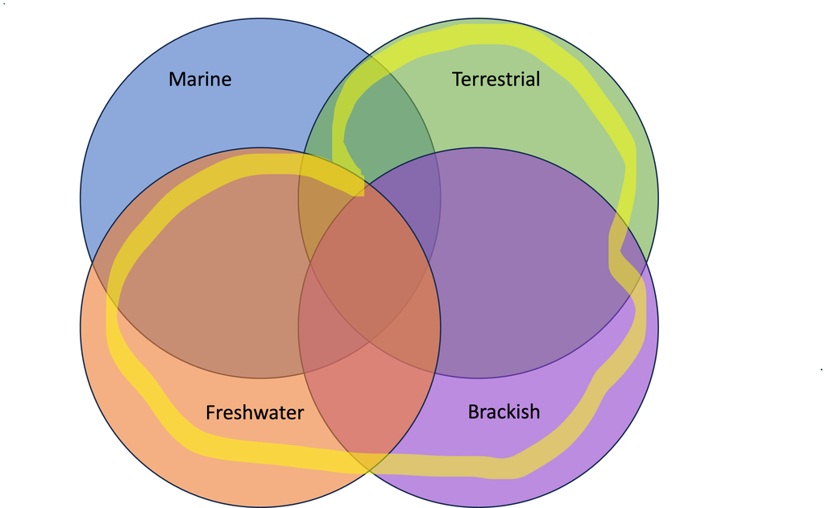

Venn diagram showing what data we want to keep

```r
nrow(accepted_noextinct_molluscs_sp)
```

```
## [1] 255
```

```r
# Not marine or missing info in Marine
accepted_noextinct_molluscs_sp |>
  filter(isMarine == 0 | is.na(isMarine)) |>
  distinct() |>
  nrow() # 117
```

```
## [1] 117
```

```r
# Taxon found in at least one habitat that we want to keep
# This is what we want
accepted_noextinct_molluscs_sp |>
  filter(isTerrestrial == TRUE | isFreshwater == TRUE | isBrackish == TRUE) |>
  distinct() |>
  nrow() #118
```

```
## [1] 118
```

```r
# accepted_noextinct_molluscs_sp |>
#   filter(isTerrestrial == TRUE | isFreshwater == TRUE | isBrackish == TRUE) |>
#   distinct() |>
#   View()

# Difference
setdiff(accepted_noextinct_molluscs_sp |>
          filter(isTerrestrial == TRUE | isFreshwater == TRUE | isBrackish == TRUE) |>
          distinct() |>
          pull(scientificname),
        accepted_noextinct_molluscs_sp |>
          filter(isMarine == 0 | is.na(isMarine)) |>
          distinct() |>
          pull(scientificname))
```

```
## [1] "Paromoionchis tumidus"
```

```r
# Found in three habitats
accepted_noextinct_molluscs_sp |>
  filter(scientificname == "Paromoionchis tumidus") |>
  select(scientificname, search_term, starts_with("is"))
```

```
## # A tibble: 1 × 7
##   scientificname      search_term isMarine isBrackish isFreshwater isTerrestrial
##   <chr>               <chr>          <int>      <int>        <int>         <int>
## 1 Paromoionchis tumi… Paromoionc…        1          1            0             1
## # ℹ 1 more variable: isExtinct <int>
```

```r
# Check: Same as above
# Covered by Taxon found in at least one habitat that we want to keep
accepted_noextinct_molluscs_sp |>
  filter(isMarine == TRUE & isTerrestrial == TRUE | isMarine == TRUE & isFreshwater == TRUE | isMarine == TRUE & isBrackish == TRUE) |>
  select(scientificname, search_term, starts_with("is"))
```

```
## # A tibble: 1 × 7
##   scientificname      search_term isMarine isBrackish isFreshwater isTerrestrial
##   <chr>               <chr>          <int>      <int>        <int>         <int>
## 1 Paromoionchis tumi… Paromoionc…        1          1            0             1
## # ℹ 1 more variable: isExtinct <int>
```

```r
# Strictly marines - to exclude
accepted_noextinct_molluscs_sp |>
  filter(isMarine == TRUE & isTerrestrial == FALSE & isFreshwater == FALSE & isBrackish == FALSE) |>
  distinct() |>
    nrow()
```

```
## [1] 126
```

```r
# accepted_noextinct_molluscs_sp |>
#   filter(isMarine == TRUE & isTerrestrial == FALSE & isFreshwater == FALSE & isBrackish == FALSE) |>
#   distinct() |>
#   View()

strictly_marines <- accepted_noextinct_molluscs_sp |>
  filter(isMarine == TRUE & isTerrestrial == FALSE & isFreshwater == FALSE & isBrackish == FALSE) |>
  distinct() |>
  pull(scientificname)

# Excluding strictly marines should be equal to Taxon found in at least one habitat that we want to keep
accepted_noextinct_molluscs_sp |>
  filter(! scientificname %in% strictly_marines) |>
  distinct() |>
  nrow() #129
```

```
## [1] 129
```

```r
# Difference
diff_taxa <- setdiff(accepted_noextinct_molluscs_sp |>
          filter(! scientificname %in% strictly_marines) |>
          distinct() |>
          pull(scientificname),
        accepted_noextinct_molluscs_sp |>
          filter(isTerrestrial == TRUE | isFreshwater == TRUE | isBrackish == TRUE) |>
          distinct() |>
          pull(scientificname))

# These are taxa where they are marine but unknown for other fields
accepted_noextinct_molluscs_sp |>
  filter(scientificname %in% diff_taxa) |>
  select(scientificname, search_term, starts_with("is"))
```

```
## # A tibble: 11 × 7
##    scientificname     search_term isMarine isBrackish isFreshwater isTerrestrial
##    <chr>              <chr>          <int>      <int>        <int>         <int>
##  1 Divalucina cumingi Divalucina…        1         NA           NA            NA
##  2 Elysia coodgeensis Elysia coo…        1         NA            0             0
##  3 Fulvia tenuicosta… Fulvia ten…        1         NA            0             0
##  4 Fustiaria nipponi… Fustiaria …        1         NA           NA            NA
##  5 Offadesma angasi   Offadesma …        1         NA           NA            NA
##  6 Ostrea edulis      Ostrea edu…        1         NA            0             0
##  7 Poroleda lanceola… Poroleda l…        1         NA           NA            NA
##  8 Rissoina flexuosa  Rissoina f…        1         NA           NA            NA
##  9 Rissoina lintea    Rissoina l…        1         NA           NA            NA
## 10 Saccostrea glomer… Saccostrea…        1         NA           NA            NA
## 11 Stoloteuthis maor… Stoloteuth…        1         NA            0             0
## # ℹ 1 more variable: isExtinct <int>
```

```r
accepted_noextinct_molluscs_sp |>
  filter(!scientificname %in% strictly_marines) |>
  filter(!is.na(isBrackish))  |>
  select(scientificname, search_term, starts_with("is")) |>
  distinct() # BAM this matches with taxon above found in at least one habitat that we want to keep
```

```
## # A tibble: 118 × 7
##    scientificname     search_term isMarine isBrackish isFreshwater isTerrestrial
##    <chr>              <chr>          <int>      <int>        <int>         <int>
##  1 Adclarkia cameroni Adclarkia …        0          0            0             1
##  2 Adclarkia dawsone… Adclarkia …        0          0            0             1
##  3 Adclarkia dulacca  Adclarkia …        0          0            0             1
##  4 Advena campbellii… Advena cam…        0          0            0             1
##  5 Aetholitis franci… Aetholitis…        0          0            0             1
##  6 Aetholitis gerdes… Aetholitis…        0          0            0             1
##  7 Aetholitis janetz… Aetholitis…        0          0            0             1
##  8 Amerianna carinata Amerianna …        0          0            1             0
##  9 Amerianna compar   Amerianna …        0          0            1             0
## 10 Amerianna reevii   Amerianna …        0          0            1             0
## # ℹ 108 more rows
## # ℹ 1 more variable: isExtinct <int>
```

```r
# To prove this:
setdiff(accepted_noextinct_molluscs_sp |>
          filter(!scientificname %in% strictly_marines) |>
          filter(!is.na(isBrackish))  |>
          select(scientificname, search_term, starts_with("is")) |>
          distinct() |>
          pull(scientificname),
        accepted_noextinct_molluscs_sp |>
          filter(isTerrestrial == TRUE | isFreshwater == TRUE | isBrackish == TRUE) |>
          distinct() |>
          pull(scientificname)
)
```

```
## character(0)
```

```r
setdiff(
        accepted_noextinct_molluscs_sp |>
          filter(isTerrestrial == TRUE | isFreshwater == TRUE | isBrackish == TRUE) |>
          distinct() |>
          pull(scientificname),
        accepted_noextinct_molluscs_sp |>
          filter(!scientificname %in% strictly_marines) |>
          filter(!is.na(isBrackish))  |>
          select(scientificname, search_term, starts_with("is")) |>
          distinct() |>
          pull(scientificname)
)
```

```
## character(0)
```

```r
# Narrow down to taxon we want
accepted_keep_taxa <- accepted_noextinct_molluscs_sp |>
  filter(isTerrestrial == TRUE | isFreshwater == TRUE | isBrackish == TRUE) |>
  distinct()
```

#### Matches to AFD

```r
matches <- intersect(accepted_keep_taxa
 |> pull(scientificname), afd_may |> pull(FULL_NAME))
```

There were 79 matches with the AFD or (1.38%) of the Australian Molluscs data provided by the Data Management Team. These are:

```r
matches
```

```
##  [1] "Adclarkia cameroni"             "Adclarkia dawsonensis"
##  [3] "Adclarkia dulacca"              "Aetholitis francisae"
##  [5] "Aetholitis gerdesae"            "Aetholitis janetzkiae"
##  [7] "Amerianna carinata"             "Amerianna compar"
##  [9] "Amerianna reevii"               "Arnhemtrachia ramingining"
## [11] "Austrocamaena ricnattrassi"     "Austropeplea hispida"
## [13] "Austropyrgus bunyaensis"        "Bayardella johni"
## [15] "Beddomeia bellii"               "Beddomeia hullii"
## [17] "Beddomeia minima"               "Beddomeia tasmanica"
## [19] "Beddomeia tumida"               "Caldicochlea harrisi"
## [21] "Coenocharopa macromphala"       "Coenocharopa multiradiata"
## [23] "Coenocharopa parvicostata"      "Coenocharopa yessabahensis"
## [25] "Cralopa kaputarensis"           "Deroceras invadens"
## [27] "Eddiella ingrami"               "Eddiella mcilwraith"
## [29] "Eddiella nana"                  "Eddiella proserpiniana"
```

[output cut: 25 more lines]

#### New taxon additions

```r
new <- setdiff(accepted_keep_taxa |> pull(scientificname), afd_may |> pull(FULL_NAME))
```

We found 39 new taxa we can add to our taxonomic checklist. These are:

```r
new
```

```
##  [1] "Advena campbellii campbellii"     "Ancylastrum cumingianum"
##  [3] "Austropeplea brazieri"            "Austropeplea huonensis"
##  [5] "Baudinella margaritata"           "Bullastra vinosa"
##  [7] "Edgbastonia alanwillsi"           "Edgbastonia chillagoensis"
##  [9] "Edgbastonia conjuboyensis"        "Edgbastonia corrugata corrugata"
## [11] "Edgbastonia corrugata umbilicata" "Edgbastonia hufferensis"
## [13] "Edgbastonia pagoda"               "Edgbastonia routhensis"
## [15] "Edgbastonia rugosa"               "Fastosarion griseolus"
## [17] "Geminitor kullaensis"             "Geminitor wenlockensis"
## [19] "Glyptophysa georgiana"            "Glyptophysa jukesii"
## [21] "Glyptophysa vandiemenensis"       "Gyraulus hesperus"
## [23] "Gyraulus meridionalis"            "Gyraulus mienanus"
## [25] "Gyraulus scottianus"              "Innesoconcha doppelganger"
## [27] "Innesoconcha segna"               "Isidorella bradshawi"
## [29] "Laspionchis boucheti"             "Laspionchis bourkei"
## [31] "Laspionchis bourkei bourkei"      "Lucidella pilsbryi"
## [33] "Molema tenuicostata"              "Paromoionchis tumidus"
## [35] "Pettancylus petterdi"             "Pravonitor septentrionalis"
## [37] "Retroterra dichroma"              "Retroterra nana"
## [39] "Sinotaia guangdungensis"
```